# Module 08 — Figures

HWC North Africa automated evidence map

2026-08-23

```r
knitr::opts_chunk$set(echo = TRUE, warning = TRUE, message = TRUE, dpi = 300)
suppressPackageStartupMessages({
  library(here); library(dplyr); library(tibble); library(readr)
  library(ggplot2); library(tidyr)
})
source(here::here("R", "config.R"))

# Okabe-Ito: designed for deuteranopia, protanopia and tritanopia, and it
# survives greyscale printing, which a conference poster may well get.
OKABE <- c("#E69F00", "#56B4E9", "#009E73", "#F0E442",
           "#0072B2", "#D55E00", "#CC79A7", "#000000")

save_fig <- function(p, name, w = 7, h = 5) {
  dir.create(here::here(DIR_FIGURES), showWarnings = FALSE, recursive = TRUE)
  ggsave(here::here(DIR_FIGURES, paste0(name, ".png")), p, width = w, height = h, dpi = 300)
  ggsave(here::here(DIR_FIGURES, paste0(name, ".svg")), p, width = w, height = h)
  p
}
```

# 1 The flow diagram

This is an **evidence-map flow diagram**, not a PRISMA-ScR diagram. It follows PRISMA’s reporting convention of showing every record and every loss, and it deliberately does not claim the design: there was no eligibility adjudication by a human reviewer at any stage, and two of the boxes hold records that were never judged at all.

```r
flow <- readr::read_csv(here::here(DIR_DERIVED, "record_flow.csv"), show_col_types = FALSE)
knitr::kable(flow |> dplyr::select(stage, n, removed, removal_reason),
             caption = "The canonical record flow (R/build_record_flow.R)")
```

The canonical record flow (R/build_record_flow.R)

| stage | n | removed | removal_reason |
| --- | --- | --- | --- |
| Records retrieved (OpenAlex + CORE, all cells) | 95546 | NA | NA |
| After deduplication | 65820 | 29726 | duplicate records merged |
| Abstract present, eligible for screening | 61065 | 4755 | no abstract: DEFERRED, not excluded |
| Screened by the ensemble | 60961 | 104 | inference failed on every attempt: DEFERRED, not excluded |
| Included by the ensemble (union rule) | 550 | 60411 | judged not eligible by both models |
| Verified as located in the five countries | 266 | 284 | located outside the five countries |
| Analytic set (study types only) | 262 | 4 | not a study (paratext, editorial) by record type |
| Analytic set with retrievable full text | 121 | 141 | no open-access full text obtainable |

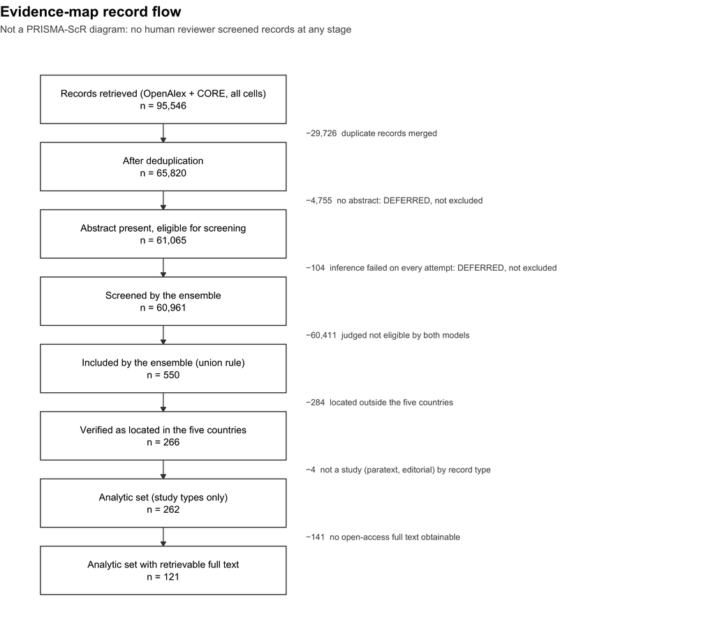

```r
lab <- flow |>
  dplyr::mutate(
    y = rev(seq_len(dplyr::n())),
    box = sprintf("%s\nn = %s", stage, format(n, big.mark = ",", trim = TRUE)),
    side = dplyr::if_else(is.na(removed), NA_character_,
                          sprintf("−%s  %s", format(removed, big.mark = ",", trim = TRUE),
                                  removal_reason)))

p <- ggplot(lab) +
  geom_rect(aes(xmin = 0, xmax = 3.1, ymin = y - 0.36, ymax = y + 0.36),
            fill = "white", colour = "grey25", linewidth = 0.4) +
  geom_text(aes(x = 1.55, y = y, label = box), size = 3.1, lineheight = 1.05) +
  geom_segment(data = lab |> dplyr::filter(y > min(y)),
               aes(x = 1.55, xend = 1.55, y = y - 0.36, yend = y - 0.64),
               arrow = arrow(length = unit(0.16, "cm"), type = "closed"),
               linewidth = 0.35, colour = "grey25") +
  geom_text(data = lab |> dplyr::filter(!is.na(side)),
            aes(x = 3.35, y = y + 0.5, label = side),
            hjust = 0, size = 2.7, colour = "grey30") +
  scale_x_continuous(limits = c(-0.1, 8.1)) +
  scale_y_continuous(expand = expansion(add = 0.6)) +
  labs(title = "Evidence-map record flow",
       subtitle = "Not a PRISMA-ScR diagram: no human reviewer screened records at any stage") +
  theme_void(base_size = 11) +
  theme(plot.title = element_text(face = "bold"),
        plot.subtitle = element_text(colour = "grey35", size = 9))
save_fig(p, "08_record_flow", w = 8.2, h = 8)
```

# 2 Classifier performance

Putting the validation on the poster is the point. A conference increasingly wary of AI-generated evidence should be able to see the measured numbers rather than take an assurance.

```r
vmet <- readr::read_csv(here::here(DIR_DERIVED, "validation_metrics.csv"),
                        show_col_types = FALSE)
deployed <- vmet |> dplyr::filter(scope == "abstract_present", polarity == "affirmative")
knitr::kable(vmet |> dplyr::select(scope, polarity, n, tp, fp, fn, tn,
                                   sensitivity, specificity, precision, f1),
             digits = 3, caption = "Ensemble performance on Bannach-Brown_2019 (SYNERGY)")
```

Ensemble performance on Bannach-Brown_2019 (SYNERGY)

| scope | polarity | n | tp | fp | fn | tn | sensitivity | specificity | precision | f1 |
| --- | --- | --- | --- | --- | --- | --- | --- | --- | --- | --- |
| all | affirmative | 198 | 25 | 23 | 3 | 147 | 0.893 | 0.865 | 0.521 | 0.658 |
| all | antonymic | 198 | 25 | 31 | 3 | 139 | 0.893 | 0.818 | 0.446 | 0.595 |
| all | negation | 198 | 24 | 18 | 4 | 152 | 0.857 | 0.894 | 0.571 | 0.686 |
| abstract_present | affirmative | 107 | 13 | 7 | 0 | 87 | 1.000 | 0.926 | 0.650 | 0.788 |
| abstract_present | antonymic | 107 | 13 | 10 | 0 | 84 | 1.000 | 0.894 | 0.565 | 0.722 |
| abstract_present | negation | 107 | 12 | 6 | 1 | 88 | 0.923 | 0.936 | 0.667 | 0.774 |

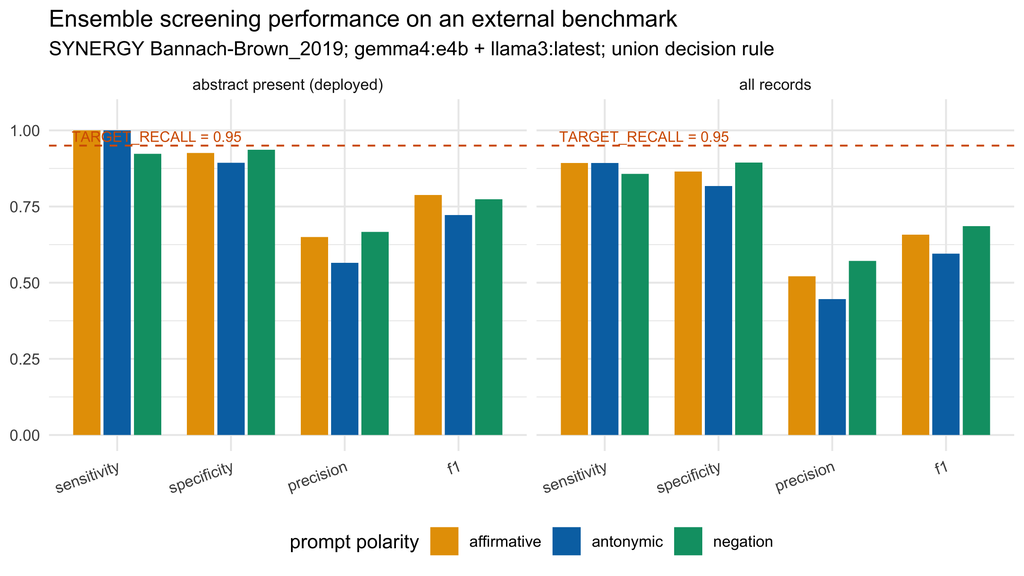

```r
perf <- vmet |>
  dplyr::select(scope, polarity, sensitivity, specificity, precision, f1) |>
  tidyr::pivot_longer(sensitivity:f1, names_to = "metric", values_to = "value") |>
  dplyr::mutate(
    scope = dplyr::recode(scope, all = "all records",
                          abstract_present = "abstract present (deployed)"),
    metric = factor(metric, c("sensitivity", "specificity", "precision", "f1")))

p <- ggplot(perf, aes(x = metric, y = value, fill = polarity)) +
  geom_col(position = position_dodge(width = 0.8), width = 0.72) +
  geom_hline(yintercept = TARGET_RECALL, linetype = "dashed", colour = OKABE[6]) +
  annotate("text", x = 0.6, y = TARGET_RECALL + 0.03,
           label = sprintf("TARGET_RECALL = %.2f", TARGET_RECALL),
           hjust = 0, size = 2.9, colour = OKABE[6]) +
  facet_wrap(~ scope) +
  scale_fill_manual(values = OKABE[c(1, 5, 3)]) +
  scale_y_continuous(limits = c(0, 1.05), breaks = seq(0, 1, 0.25)) +
  labs(x = NULL, y = NULL, fill = "prompt polarity",
       title = "Ensemble screening performance on an external benchmark",
       subtitle = sprintf("SYNERGY Bannach-Brown_2019; %s; union decision rule",
                          paste(ENSEMBLE_MODELS, collapse = " + "))) +
  theme_minimal(base_size = 11) +
  theme(legend.position = "bottom",
        axis.text.x = element_text(angle = 20, hjust = 1))
save_fig(p, "08_classifier_performance", w = 8, h = 4.5)
```

```r
ci <- binom.test(deployed$tp, deployed$tp + deployed$fn)$conf.int
```

```
## `height` was translated to `width`.
## `height` was translated to `width`.
## `height` was translated to `width`.
```

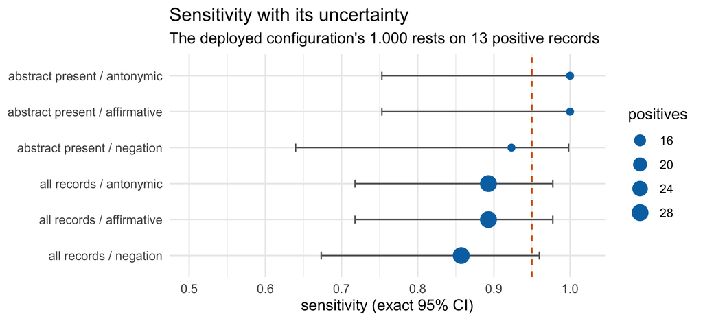

```r
cis <- vmet |>
  dplyr::rowwise() |>
  dplyr::mutate(lo = binom.test(tp, tp + fn)$conf.int[1],
                hi = binom.test(tp, tp + fn)$conf.int[2],
                label = sprintf("%s / %s",
                                dplyr::recode(scope, all = "all records",
                                              abstract_present = "abstract present"),
                                polarity)) |>
  dplyr::ungroup()

# Axis starts at 0.5, not 0. These are points with intervals rather than bars,
# so no length is being read as a magnitude, and the whole story lives between
# 0.64 and 1.00 -- a full-range axis compresses every interval into the right
# third and hides exactly the uncertainty the figure exists to show.
p <- ggplot(cis, aes(x = sensitivity, y = reorder(label, sensitivity))) +
  geom_vline(xintercept = TARGET_RECALL, linetype = "dashed", colour = OKABE[6]) +
  geom_errorbarh(aes(xmin = lo, xmax = hi), height = 0.22, colour = "grey40") +
  geom_point(aes(size = tp + fn), colour = OKABE[5]) +
  scale_x_continuous(limits = c(0.5, 1.02), breaks = seq(0.5, 1, 0.1)) +
  scale_size_continuous(range = c(2, 5), name = "positives") +
  labs(x = "sensitivity (exact 95% CI)", y = NULL,
       title = "Sensitivity with its uncertainty",
       subtitle = "The deployed configuration's 1.000 rests on 13 positive records") +
  theme_minimal(base_size = 11)
save_fig(p, "08_sensitivity_ci", w = 7, h = 3.2)
```